# Swiggy Restaurant Market Analysis: Cuisine & City Expansion Opportunities

## Exploratory Data Analysis

**City Landscape** Restaurant presence is heavily concentrated in major metros — Bangalore (14,943), Delhi (14,081), and Pune (12,441) lead by volume. Average ratings are remarkably consistent across all major cities (3.79–4.08), suggesting city alone does not meaningfully differentiate restaurant quality on the platform. Average cost varies more (₹247–₹358); notably, Bikaner shows the highest average cost (₹358) despite having far fewer restaurants (1,666) than the top metros. This is not a data artifact — Bikaner’s maximum cost value is ₹1,000, well within normal range — and instead suggests a smaller, more premium-skewed restaurant base rather than a mass-market one. Mumbai is the only major metro with a notably elevated average cost (₹340) relative to its peers.

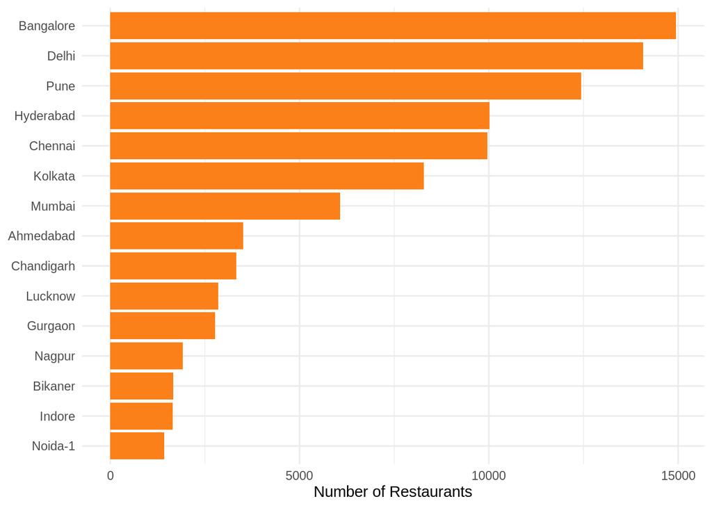

Figure 1: Top 15 Cities by Restaurant Count

```r
city_summary %>%
  slice_max(n_restaurants, n = 15) %>%
  ggplot(aes(x = reorder(city, n_restaurants), y = n_restaurants)) +
  geom_col(fill = "#fc8019") +
  coord_flip() +
  labs(x = NULL, y = "Number of Restaurants") +
  theme_minimal()
```

**Cuisine Landscape** Chinese (36,464 listings) and North Indian (32,537) dominate nationally, followed by Indian, Snacks, and Biryani. Note: “Chinese” on Indian food delivery platforms typically refers to Indo-Chinese fusion cuisine (e.g., Gobi Manchurian, Hakka Noodles) rather than authentic Chinese cuisine — a distinction worth keeping in mind when interpreting cuisine-based recommendations.

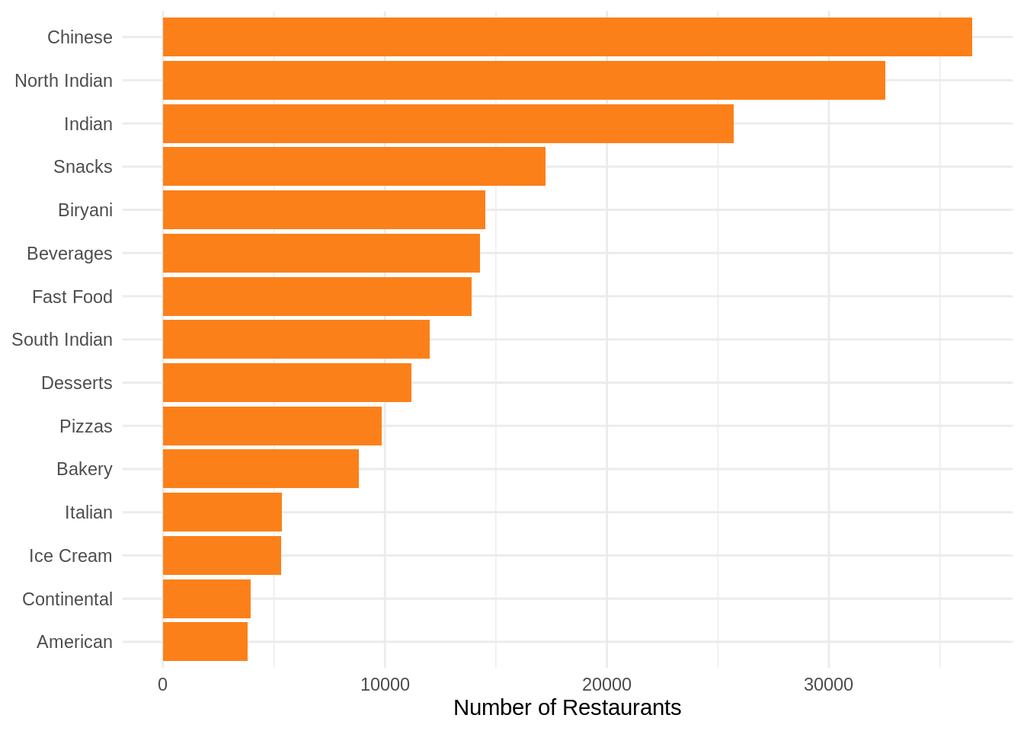

Figure 2: Top 15 Cuisines by Restaurant Count

```r
cuisine_long %>%
  count(cuisine, sort = TRUE) %>%
  slice_max(n, n = 15) %>%
  ggplot(aes(x = reorder(cuisine, n), y = n)) +
  geom_col(fill = "#fc8019") +
  coord_flip() +
  labs(x = NULL, y = "Number of Restaurants") +
  theme_minimal()
```

**Rating Distribution** Ratings are only available for 41% of restaurants; the remaining 59% are unrated (“Too Few Ratings”), a pattern established during cleaning as structural rather than random. Among rated restaurants, ratings cluster between 3.5–4.2, with very few restaurants below 2.5 or above 4.5.

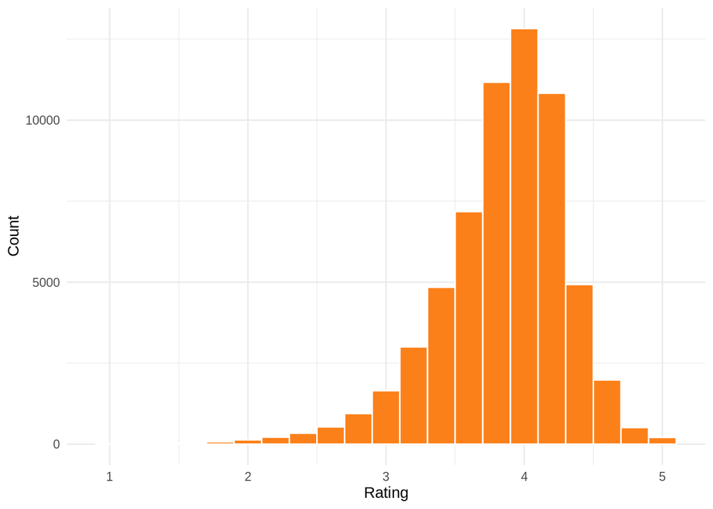

Rating Distribution (Rated Restaurants Only)

```r
clean %>%
  filter(!is.na(rating)) %>%
  ggplot(aes(x = rating)) +
  geom_histogram(binwidth = 0.2, fill = "#fc8019", color = "white") +
  labs(x = "Rating", y = "Count") +
  theme_minimal()
```

**Cost Distribution** Cost is right-skewed, with the bulk of restaurants priced between ₹100–₹350, and a long tail of higher-cost outliers beyond that.

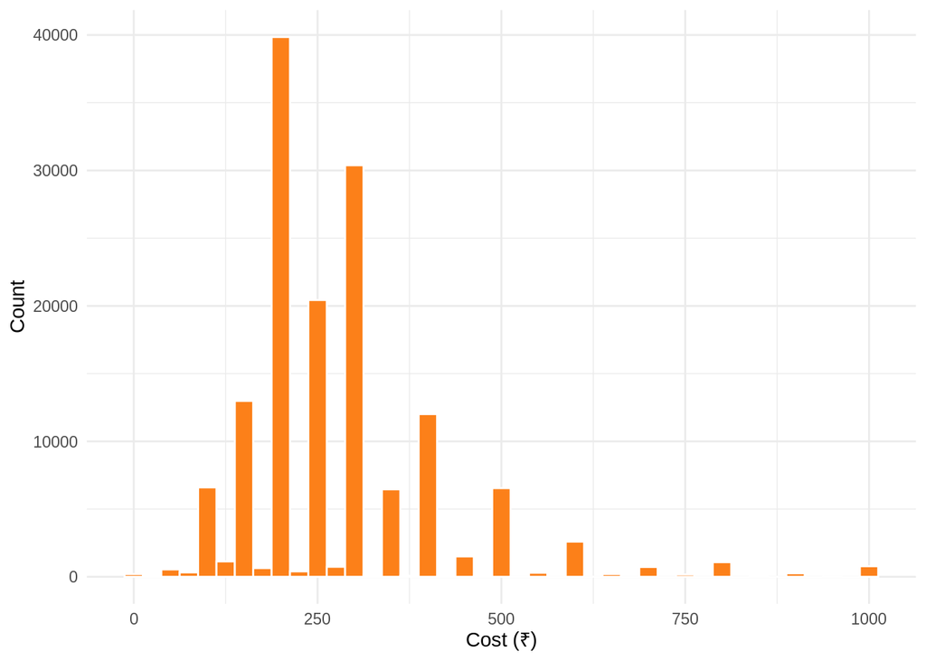

Cost Distribution

```r
clean %>%
  filter(!is.na(cost)) %>%
  ggplot(aes(x = cost)) +
  geom_histogram(binwidth = 25, fill = "#fc8019", color = "white") +
  labs(x = "Cost (₹)", y = "Count") +
  theme_minimal()
```

**Cost vs. Rating** A correlation of 0.136 between cost and rating indicates price is not a meaningful predictor of restaurant quality on this platform — higher-priced restaurants are not reliably better-rated than lower-priced ones.

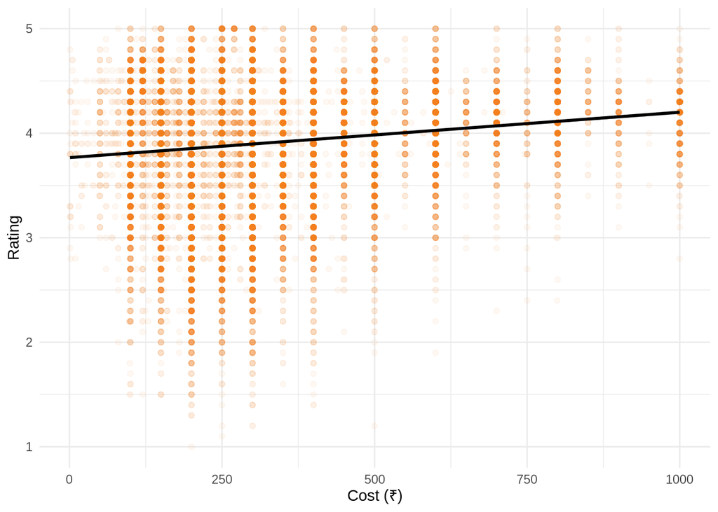

Cost vs. Rating

```r
clean %>%
  filter(!is.na(rating), !is.na(cost)) %>%
  ggplot(aes(x = cost, y = rating)) +
  geom_point(alpha = 0.05, color = "#fc8019") +
  geom_smooth(method = "lm", color = "black") +
  labs(x = "Cost (₹)", y = "Rating") +
  theme_minimal()
```